# Moral ID and COVID

Alternative Analysis

Cillian McHugh

21st May 2021

# Introduction

[Introduction is here](https://docs.google.com/document/d/1mDV7E6DE7lUiBEDMDcoaAhFGffB4TgVT1DAzisn6kWE/edit?usp=sharing)

# Method

## Participants

A total of sample of *N* = 46450 participants (22160, female, 23948 male, 139 other, *M*<sub>age</sub> = 43.09, min = 18, max = 100, *SD* = 16.22), were recruited from 67 countries.

I isolated just the participants in USA and NZL, leaving a total of *N* = 1980 participants (965, female, 1008 male, 5 other, *M*<sub>age</sub> = 44.7, min = 18, max = 100, *SD* = 16.76). The USA sample consisted of *n* = 1471 participants (710, female, 755 male, 4 other, *M*<sub>age</sub> = 44.32; and the New Zealand sample consisted of *n* = 509 participants (255, female, 253 male, 1 other, *M*<sub>age</sub> = 45.78.

# Policy Support

## Without Country

First I ran a regression for all variables across the full dataset (without accounting for Country). This model was significant $R^2 = .24$, $F(14, 1939) = 44.35$, $p < .001$.

Table 1:

*Predictors of Policy Support (without Country)*

| Predictor | $b$ | 95% CI | $t(1939)$ | $p$ |
| --- | --- | --- | --- | --- |
| Intercept | 0.41 | $[0.28$, $0.54]$ | 6.34 | < .001 |
| Risk perception tot | 0.12 | $[0.08$, $0.16]$ | 5.62 | < .001 |
| Narcissism admiration tot | 0.02 | $[-0.03$, $0.08]$ | 0.92 | .357 |
| Narcissism rivalry tot | 0.04 | $[-0.01$, $0.09]$ | 1.67 | .095 |
| Collective narcissism tot | 0.16 | $[0.10$, $0.22]$ | 5.29 | < .001 |
| Conspiracy tot | -0.26 | $[-0.31$, $-0.21]$ | -10.15 | < .001 |
| National ID tot | 0.13 | $[0.08$, $0.19]$ | 4.82 | < .001 |
| Moral circle | 0.05 | $[0.01$, $0.09]$ | 2.31 | .021 |
| Moral identity internal | 0.52 | $[0.41$, $0.63]$ | 9.14 | < .001 |
| Moral identity symbolic | -0.12 | $[-0.23$, $-0.01]$ | -2.12 | .034 |
| Political ideology | -0.07 | $[-0.09$, $-0.05]$ | -7.19 | < .001 |
| Moral circle $\times$ Moral identity internal | 0.00 | $[-0.04$, $0.03]$ | -0.22 | .823 |
| Moral circle $\times$ Moral identity symbolic | 0.04 | $[0.00$, $0.07]$ | 1.77 | .076 |
| Moral identity internal $\times$ Political ideology | -0.04 | $[-0.06$, $-0.03]$ | -5.85 | < .001 |
| Moral identity symbolic $\times$ Political ideology | 0.04 | $[0.02$, $0.05]$ | 5.25 | < .001 |

## With Country

Next I added Country as an interaction term. Again the model was significant $R^2 = .29$, $F(29, 1924) = 27.63$, $p < .001$. And the model performed significantly better than the previous model *F*(15, 1924) = 9.35, *p* < .001. Most interestingly, the three way interaction between Country, Political Ideology, and Moral Identity Internal is there:

Table 2:

*3 way interaction*

|  | Predictor | $b$ | 95% CI | $t(1924)$ | $p$ |
| --- | --- | --- | --- | --- | --- |
| 29 | Country $\times$ Moral identity internal $\times$ Political ideology | 0.06 | $[0.02$, $0.10]$ | 2.76 | .006 |

Table 3:

*Predictors of Policy Support (with Country)*

| Predictor | $b$ | 95% CI | $t(1924)$ | $p$ |
| --- | --- | --- | --- | --- |
| Intercept | 0.31 | $[0.17$, $0.46]$ | 4.20 | < .001 |
| Country | 0.03 | $[-0.26$, $0.33]$ | 0.23 | .819 |
| Risk perception tot | 0.20 | $[0.15$, $0.25]$ | 8.09 | < .001 |
| Narcissism admiration tot | 0.07 | $[0.01$, $0.12]$ | 2.19 | .029 |
| Narcissism rivalry tot | 0.01 | $[-0.04$, $0.07]$ | 0.47 | .638 |
| Collective narcissism tot | 0.13 | $[0.06$, $0.19]$ | 3.63 | < .001 |
| Conspiracy tot | -0.23 | $[-0.29$, $-0.17]$ | -7.89 | < .001 |
| National ID tot | 0.14 | $[0.08$, $0.20]$ | 4.27 | < .001 |
| Moral circle | 0.07 | $[0.02$, $0.12]$ | 2.90 | .004 |
| Moral identity internal | 0.55 | $[0.43$, $0.67]$ | 8.76 | < .001 |
| Moral identity symbolic | -0.13 | $[-0.25$, $-0.01]$ | -2.08 | .038 |
| Political ideology | -0.07 | $[-0.10$, $-0.05]$ | -6.93 | < .001 |
| Moral circle $\times$ Moral identity internal | 0.00 | $[-0.04$, $0.05]$ | 0.17 | .863 |
| Moral circle $\times$ Moral identity symbolic | 0.03 | $[-0.01$, $0.07]$ | 1.38 | .167 |
| Moral identity internal $\times$ Political ideology | -0.05 | $[-0.06$, $-0.03]$ | -5.86 | < .001 |
| Moral identity symbolic $\times$ Political ideology | 0.04 | $[0.03$, $0.06]$ | 5.70 | < .001 |
| Country $\times$ Risk perception tot | -0.16 | $[-0.26$, $-0.06]$ | -3.10 | .002 |
| Country $\times$ Narcissism admiration tot | -0.12 | $[-0.24$, $0.00]$ | -1.89 | .059 |
| Country $\times$ Narcissism rivalry tot | 0.03 | $[-0.09$, $0.15]$ | 0.47 | .635 |
| Country $\times$ Collective narcissism tot | 0.03 | $[-0.10$, $0.16]$ | 0.49 | .625 |
| Country $\times$ Conspiracy tot | 0.02 | $[-0.10$, $0.13]$ | 0.27 | .788 |
| Country $\times$ National ID tot | -0.02 | $[-0.13$, $0.10]$ | -0.32 | .751 |
| Country $\times$ Moral circle | -0.06 | $[-0.15$, $0.03]$ | -1.36 | .176 |
| Country $\times$ Moral identity internal | -0.40 | $[-0.68$, $-0.12]$ | -2.83 | .005 |
| Country $\times$ Moral identity symbolic | 0.05 | $[-0.23$, $0.33]$ | 0.32 | .748 |
| Country $\times$ Political ideology | 0.06 | $[0.02$, $0.11]$ | 2.76 | .006 |
| Country $\times$ Moral circle $\times$ Moral identity internal | -0.02 | $[-0.11$, $0.07]$ | -0.37 | .709 |
| Country $\times$ Moral circle $\times$ Moral identity symbolic | -0.02 | $[-0.11$, $0.08]$ | -0.32 | .750 |
| Country $\times$ Moral identity internal $\times$ Political ideology | 0.06 | $[0.02$, $0.10]$ | 2.76 | .006 |
| Country $\times$ Moral identity symbolic $\times$ Political ideology | -0.02 | $[-0.06$, $0.02]$ | -1.20 | .229 |

## Plot

Figure 1 shows the relationship between Political Ideology and Internal Moral Identity in predicting Policy Support for the New Zealand sample and the USA sample separately.

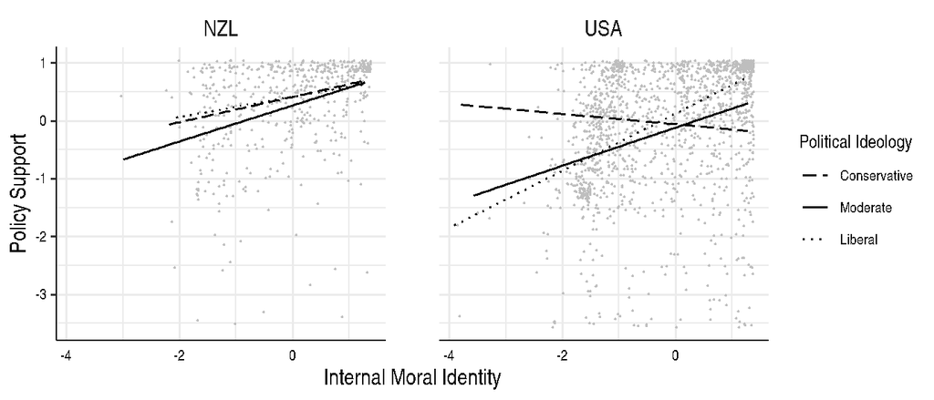

Figure 1: USA: Interaction between Political Ideology and Internal Moral Identity in predicting Policy Support

## USA Regression

This model was significant $R^2 = .29$, $F(14, 1437) = 41.16$, $p < .001$.

Table 4:

*Predictors of Policy Support in USA*

| Predictor | $b$ | 95% CI | $t(1437)$ | $p$ |
| --- | --- | --- | --- | --- |
| Intercept | 0.31 | $[0.16$, $0.47]$ | 4.03 | < .001 |
| Risk perception tot | 0.20 | $[0.15$, $0.25]$ | 7.76 | < .001 |
| Narcissism admiration tot | 0.07 | $[0.00$, $0.13]$ | 2.10 | .036 |
| Narcissism rivalry tot | 0.01 | $[-0.05$, $0.07]$ | 0.45 | .651 |
| Collective narcissism tot | 0.13 | $[0.05$, $0.20]$ | 3.48 | .001 |
| Conspiracy tot | -0.23 | $[-0.29$, $-0.17]$ | -7.57 | < .001 |
| National ID tot | 0.14 | $[0.07$, $0.21]$ | 4.10 | < .001 |
| Moral circle | 0.07 | $[0.02$, $0.12]$ | 2.78 | .006 |
| Moral identity internal | 0.55 | $[0.42$, $0.68]$ | 8.40 | < .001 |
| Moral identity symbolic | -0.13 | $[-0.25$, $0.00]$ | -1.99 | .047 |
| Political ideology | -0.07 | $[-0.10$, $-0.05]$ | -6.65 | < .001 |
| Moral circle $\times$ Moral identity internal | 0.00 | $[-0.04$, $0.05]$ | 0.17 | .868 |
| Moral circle $\times$ Moral identity symbolic | 0.03 | $[-0.01$, $0.08]$ | 1.33 | .185 |
| Moral identity internal $\times$ Political ideology | -0.05 | $[-0.06$, $-0.03]$ | -5.62 | < .001 |
| Moral identity symbolic $\times$ Political ideology | 0.04 | $[0.03$, $0.06]$ | 5.47 | < .001 |

## New Zealand Regression

This model was significant $R^2 = .19$, $F(14, 487) = 8.20$, $p < .001$.

Table 5:

*Predictors of Policy Support in New Zealand*

| Predictor | $b$ | 95% CI | $t(487)$ | $p$ |
| --- | --- | --- | --- | --- |
| Intercept | 0.35 | $[0.12$, $0.57]$ | 3.04 | .002 |
| Risk perception tot | 0.04 | $[-0.04$, $0.12]$ | 0.99 | .323 |
| Narcissism admiration tot | -0.05 | $[-0.14$, $0.04]$ | -1.10 | .271 |
| Narcissism rivalry tot | 0.04 | $[-0.05$, $0.14]$ | 0.91 | .365 |
| Collective narcissism tot | 0.16 | $[0.06$, $0.25]$ | 3.23 | .001 |
| Conspiracy tot | -0.22 | $[-0.30$, $-0.14]$ | -5.26 | < .001 |
| National ID tot | 0.12 | $[0.04$, $0.20]$ | 2.93 | .003 |
| Moral circle | 0.01 | $[-0.06$, $0.07]$ | 0.22 | .824 |
| Moral identity internal | 0.15 | $[-0.07$, $0.36]$ | 1.34 | .181 |
| Moral identity symbolic | -0.08 | $[-0.30$, $0.14]$ | -0.73 | .466 |
| Political ideology | -0.01 | $[-0.05$, $0.02]$ | -0.77 | .441 |
| Moral circle $\times$ Moral identity internal | -0.01 | $[-0.08$, $0.06]$ | -0.38 | .701 |
| Moral circle $\times$ Moral identity symbolic | 0.01 | $[-0.06$, $0.09]$ | 0.40 | .687 |
| Moral identity internal $\times$ Political ideology | 0.01 | $[-0.02$, $0.04]$ | 0.60 | .549 |
| Moral identity symbolic $\times$ Political ideology | 0.02 | $[-0.01$, $0.05]$ | 1.27 | .205 |

# Physical Contact

## Without Country

First I ran a regression for all variables across the full dataset (without accounting for Country). This model was significant $R^2 = .36$, $F(14, 1939) = 77.66$, $p < .001$.

Table 6:

*Predictors of Physical Contact (without Country)*

| Predictor | $b$ | 95% CI | $t(1939)$ | $p$ |
| --- | --- | --- | --- | --- |
| Intercept | 0.07 | $[-0.05$, $0.19]$ | 1.13 | .258 |
| Risk perception tot | 0.04 | $[0.00$, $0.08]$ | 1.74 | .082 |
| Narcissism admiration tot | -0.04 | $[-0.09$, $0.01]$ | -1.70 | .090 |
| Narcissism rivalry tot | -0.10 | $[-0.15$, $-0.05]$ | -4.11 | < .001 |
| Collective narcissism tot | 0.05 | $[-0.01$, $0.10]$ | 1.66 | .097 |
| Conspiracy tot | -0.20 | $[-0.25$, $-0.16]$ | -8.36 | < .001 |
| National ID tot | 0.18 | $[0.13$, $0.24]$ | 6.97 | < .001 |
| Moral circle | 0.02 | $[-0.02$, $0.06]$ | 1.11 | .269 |
| Moral identity internal | 0.49 | $[0.38$, $0.59]$ | 9.01 | < .001 |
| Moral identity symbolic | -0.12 | $[-0.22$, $-0.01]$ | -2.15 | .032 |
| Political ideology | -0.02 | $[-0.04$, $0.00]$ | -2.12 | .034 |
| Moral circle $\times$ Moral identity internal | -0.01 | $[-0.05$, $0.02]$ | -0.72 | .470 |
| Moral circle $\times$ Moral identity symbolic | 0.05 | $[0.01$, $0.09]$ | 2.61 | .009 |
| Moral identity internal $\times$ Political ideology | -0.02 | $[-0.03$, $-0.01]$ | -2.82 | .005 |
| Moral identity symbolic $\times$ Political ideology | 0.02 | $[0.01$, $0.04]$ | 3.49 | < .001 |

## With Country

Next I added Country as an interaction term. Again the model was significant $R^2 = .41$, $F(29, 1924) = 46.19$, $p < .001$. And the model performed significantly better than the previous model *F*(15, 1924) = 11.13, *p* < .001. Again a three way interaction was observed.

Table 7:

*3 way interaction*

|  | Predictor | $b$ | 95% CI | $t(1924)$ | $p$ |
| --- | --- | --- | --- | --- | --- |
| 29 | Country $\times$ Moral identity internal $\times$ Political ideology | 0.04 | $[0.01$, $0.08]$ | 2.27 | .023 |

Table 8:

*Predictors of Physical Contact (with Country)*

| Predictor | $b$ | 95% CI | $t(1924)$ | $p$ |
| --- | --- | --- | --- | --- |
| Intercept | -0.05 | $[-0.19$, $0.09]$ | -0.68 | .498 |
| Country | 0.16 | $[-0.13$, $0.44]$ | 1.08 | .282 |
| Risk perception tot | 0.11 | $[0.07$, $0.16]$ | 4.77 | < .001 |
| Narcissism admiration tot | -0.03 | $[-0.08$, $0.03]$ | -0.96 | .337 |
| Narcissism rivalry tot | -0.11 | $[-0.17$, $-0.06]$ | -4.14 | < .001 |
| Collective narcissism tot | 0.00 | $[-0.06$, $0.07]$ | 0.11 | .912 |
| Conspiracy tot | -0.18 | $[-0.24$, $-0.13]$ | -6.58 | < .001 |
| National ID tot | 0.21 | $[0.15$, $0.27]$ | 6.69 | < .001 |
| Moral circle | 0.05 | $[0.00$, $0.09]$ | 1.94 | .053 |
| Moral identity internal | 0.53 | $[0.41$, $0.64]$ | 8.84 | < .001 |
| Moral identity symbolic | -0.11 | $[-0.23$, $0.00]$ | -1.96 | .051 |
| Political ideology | -0.02 | $[-0.04$, $0.00]$ | -2.26 | .024 |
| Moral circle $\times$ Moral identity internal | 0.00 | $[-0.05$, $0.04]$ | -0.24 | .814 |
| Moral circle $\times$ Moral identity symbolic | 0.04 | $[0.00$, $0.09]$ | 2.13 | .033 |
| Moral identity internal $\times$ Political ideology | -0.02 | $[-0.04$, $-0.01]$ | -2.97 | .003 |
| Moral identity symbolic $\times$ Political ideology | 0.03 | $[0.02$, $0.05]$ | 4.19 | < .001 |
| Country $\times$ Risk perception tot | -0.15 | $[-0.25$, $-0.06]$ | -3.13 | .002 |
| Country $\times$ Narcissism admiration tot | 0.00 | $[-0.12$, $0.11]$ | -0.04 | .967 |
| Country $\times$ Narcissism rivalry tot | -0.06 | $[-0.17$, $0.06]$ | -0.94 | .345 |
| Country $\times$ Collective narcissism tot | 0.06 | $[-0.07$, $0.18]$ | 0.90 | .368 |
| Country $\times$ Conspiracy tot | 0.05 | $[-0.05$, $0.16]$ | 1.00 | .316 |
| Country $\times$ National ID tot | -0.08 | $[-0.18$, $0.03]$ | -1.37 | .171 |
| Country $\times$ Moral circle | -0.06 | $[-0.15$, $0.03]$ | -1.36 | .173 |
| Country $\times$ Moral identity internal | -0.39 | $[-0.66$, $-0.13]$ | -2.91 | .004 |
| Country $\times$ Moral identity symbolic | 0.01 | $[-0.26$, $0.27]$ | 0.06 | .952 |
| Country $\times$ Political ideology | 0.05 | $[0.01$, $0.09]$ | 2.22 | .027 |
| Country $\times$ Moral circle $\times$ Moral identity internal | -0.02 | $[-0.11$, $0.06]$ | -0.49 | .626 |
| Country $\times$ Moral circle $\times$ Moral identity symbolic | -0.03 | $[-0.12$, $0.06]$ | -0.59 | .556 |
| Country $\times$ Moral identity internal $\times$ Political ideology | 0.04 | $[0.01$, $0.08]$ | 2.27 | .023 |
| Country $\times$ Moral identity symbolic $\times$ Political ideology | -0.03 | $[-0.06$, $0.01]$ | -1.37 | .170 |

## Plot

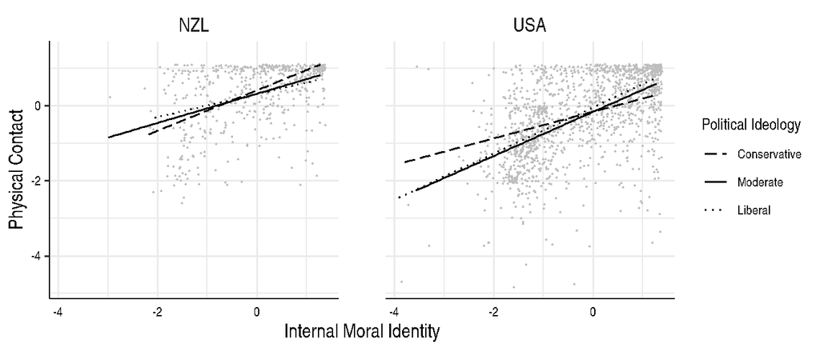

## USA Regression

Table 9:

[output not shown]

## New Zealand Regression

Table 10:

[output not shown]

# Physical Hygiene

## Without Country

First I ran a regression for all variables across the full dataset (without accounting for Country). This model was significant $R^2 = .26$, $F(14, 1938) = 48.93$, $p < .001$.

Table 11:

*Predictors of Physical Hygiene (without Country)*

| Predictor | $b$ | 95% CI | $t(1938)$ | $p$ |
| --- | --- | --- | --- | --- |
| Intercept | -0.12 | $[-0.24$, $0.01]$ | -1.86 | .063 |
| Risk perception tot | 0.13 | $[0.09$, $0.17]$ | 6.19 | < .001 |
| Narcissism admiration tot | 0.08 | $[0.03$, $0.13]$ | 3.15 | .002 |
| Narcissism rivalry tot | -0.12 | $[-0.17$, $-0.07]$ | -4.71 | < .001 |
| Collective narcissism tot | 0.16 | $[0.10$, $0.21]$ | 5.39 | < .001 |
| Conspiracy tot | -0.07 | $[-0.12$, $-0.02]$ | -2.87 | .004 |
| National ID tot | 0.16 | $[0.11$, $0.22]$ | 6.08 | < .001 |
| Moral circle | 0.02 | $[-0.02$, $0.07]$ | 1.19 | .235 |
| Moral identity internal | 0.36 | $[0.25$, $0.47]$ | 6.50 | < .001 |
| Moral identity symbolic | 0.15 | $[0.05$, $0.26]$ | 2.79 | .005 |
| Political ideology | 0.00 | $[-0.02$, $0.02]$ | 0.00 | .999 |
| Moral circle $\times$ Moral identity internal | 0.02 | $[-0.02$, $0.06]$ | 1.11 | .265 |
| Moral circle $\times$ Moral identity symbolic | 0.01 | $[-0.03$, $0.05]$ | 0.48 | .628 |
| Moral identity internal $\times$ Political ideology | -0.02 | $[-0.04$, $-0.01]$ | -3.03 | .002 |
| Moral identity symbolic $\times$ Political ideology | 0.01 | $[0.00$, $0.03]$ | 1.61 | .108 |

## With Country

Next I added Country as an interaction term. Again the model was significant $R^2 = .28$, $F(29, 1923) = 25.33$, $p < .001$. And the model performed significantly better than the previous model *F*(15, 1923) = 2.71, *p* < .001. No three way interaction this time.

Table 12:

*Predictors of Physical Hygiene (with Country)*

| Predictor | $b$ | 95% CI | $t(1923)$ | $p$ |
| --- | --- | --- | --- | --- |
| Intercept | -0.03 | $[-0.18$, $0.11]$ | -0.44 | .657 |
| Country | -0.24 | $[-0.54$, $0.06]$ | -1.55 | .121 |
| Risk perception tot | 0.14 | $[0.09$, $0.19]$ | 5.74 | < .001 |
| Narcissism admiration tot | 0.08 | $[0.02$, $0.14]$ | 2.63 | .008 |
| Narcissism rivalry tot | -0.11 | $[-0.17$, $-0.05]$ | -3.84 | < .001 |
| Collective narcissism tot | 0.16 | $[0.10$, $0.23]$ | 4.73 | < .001 |
| Conspiracy tot | -0.09 | $[-0.15$, $-0.03]$ | -3.03 | .003 |
| National ID tot | 0.20 | $[0.14$, $0.27]$ | 6.11 | < .001 |
| Moral circle | 0.02 | $[-0.03$, $0.07]$ | 0.81 | .416 |
| Moral identity internal | 0.39 | $[0.26$, $0.51]$ | 6.15 | < .001 |
| Moral identity symbolic | 0.13 | $[0.01$, $0.25]$ | 2.16 | .031 |
| Political ideology | -0.01 | $[-0.03$, $0.02]$ | -0.50 | .620 |
| Moral circle $\times$ Moral identity internal | 0.03 | $[-0.02$, $0.07]$ | 1.19 | .236 |
| Moral circle $\times$ Moral identity symbolic | 0.02 | $[-0.02$, $0.06]$ | 0.89 | .375 |
| Moral identity internal $\times$ Political ideology | -0.02 | $[-0.04$, $-0.01]$ | -2.84 | .005 |
| Moral identity symbolic $\times$ Political ideology | 0.01 | $[0.00$, $0.03]$ | 1.56 | .119 |
| Country $\times$ Risk perception tot | -0.16 | $[-0.26$, $-0.05]$ | -3.01 | .003 |
| Country $\times$ Narcissism admiration tot | -0.02 | $[-0.14$, $0.10]$ | -0.36 | .722 |
| Country $\times$ Narcissism rivalry tot | -0.02 | $[-0.14$, $0.11]$ | -0.24 | .807 |
| Country $\times$ Collective narcissism tot | 0.02 | $[-0.11$, $0.15]$ | 0.35 | .725 |
| Country $\times$ Conspiracy tot | 0.08 | $[-0.03$, $0.19]$ | 1.47 | .143 |
| Country $\times$ National ID tot | -0.13 | $[-0.24$, $-0.02]$ | -2.22 | .026 |
| Country $\times$ Moral circle | 0.01 | $[-0.08$, $0.11]$ | 0.31 | .757 |
| Country $\times$ Moral identity internal | 0.01 | $[-0.27$, $0.29]$ | 0.09 | .926 |
| Country $\times$ Moral identity symbolic | 0.09 | $[-0.19$, $0.38]$ | 0.65 | .513 |
| Country $\times$ Political ideology | 0.00 | $[-0.04$, $0.05]$ | 0.05 | .957 |
| Country $\times$ Moral circle $\times$ Moral identity internal | -0.02 | $[-0.12$, $0.07]$ | -0.53 | .593 |
| Country $\times$ Moral circle $\times$ Moral identity symbolic | -0.08 | $[-0.17$, $0.02]$ | -1.58 | .113 |
| Country $\times$ Moral identity internal $\times$ Political ideology | -0.02 | $[-0.06$, $0.02]$ | -0.97 | .332 |
| Country $\times$ Moral identity symbolic $\times$ Political ideology | -0.01 | $[-0.05$, $0.03]$ | -0.64 | .521 |

## Plot

Figure 3 shows the relationship between Political Ideology and Internal Moral Identity in predicting Physical Hygiene for the New Zealand sample and the USA sample separately (note that these effects are equivalent).

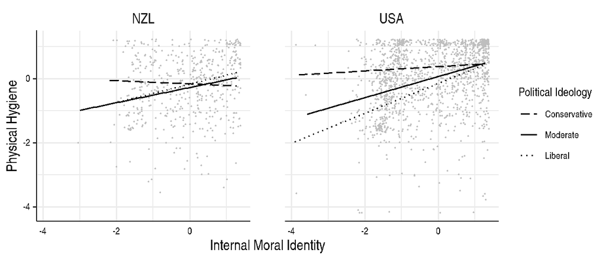

Figure 3: USA: Interaction between Political Ideology and Internal Moral Identity in predicting Physical Hygiene

## USA Regression

This model was significant $R^2 = .30$, $F(14, 1436) = 44.01$, $p < .001$.

Table 13:

*Predictors of Adherence to Physical Hygiene measures in USA*

| Predictor | $b$ | 95% CI | $t(1436)$ | $p$ |
| --- | --- | --- | --- | --- |
| Intercept | -0.03 | $[-0.18$, $0.11]$ | -0.45 | .651 |
| Risk perception tot | 0.14 | $[0.09$, $0.19]$ | 5.86 | < .001 |
| Narcissism admiration tot | 0.08 | $[0.02$, $0.14]$ | 2.69 | .007 |
| Narcissism rivalry tot | -0.11 | $[-0.17$, $-0.06]$ | -3.92 | < .001 |
| Collective narcissism tot | 0.16 | $[0.10$, $0.23]$ | 4.82 | < .001 |
| Conspiracy tot | -0.09 | $[-0.15$, $-0.03]$ | -3.09 | .002 |
| National ID tot | 0.20 | $[0.14$, $0.26]$ | 6.23 | < .001 |
| Moral circle | 0.02 | $[-0.03$, $0.07]$ | 0.83 | .407 |
| Moral identity internal | 0.39 | $[0.27$, $0.51]$ | 6.27 | < .001 |
| Moral identity symbolic | 0.13 | $[0.01$, $0.25]$ | 2.20 | .028 |
| Political ideology | -0.01 | $[-0.03$, $0.02]$ | -0.51 | .613 |
| Moral circle $\times$ Moral identity internal | 0.03 | $[-0.02$, $0.07]$ | 1.21 | .226 |
| Moral circle $\times$ Moral identity symbolic | 0.02 | $[-0.02$, $0.06]$ | 0.91 | .365 |
| Moral identity internal $\times$ Political ideology | -0.02 | $[-0.04$, $-0.01]$ | -2.89 | .004 |
| Moral identity symbolic $\times$ Political ideology | 0.01 | $[0.00$, $0.03]$ | 1.59 | .112 |

## New Zealand Regression

This model was significant $R^2 = .16$, $F(14, 487) = 6.73$, $p < .001$.

Table 14:

*Predictors of Adherence to Physical Hygiene measures in New Zealand*

| Predictor | $b$ | 95% CI | $t(487)$ | $p$ |
| --- | --- | --- | --- | --- |
| Intercept | -0.27 | $[-0.55$, $0.01]$ | -1.92 | .056 |
| Risk perception tot | -0.01 | $[-0.11$, $0.08]$ | -0.30 | .768 |
| Narcissism admiration tot | 0.06 | $[-0.06$, $0.17]$ | 0.99 | .323 |
| Narcissism rivalry tot | -0.13 | $[-0.24$, $-0.01]$ | -2.16 | .032 |
| Collective narcissism tot | 0.19 | $[0.07$, $0.31]$ | 3.11 | .002 |
| Conspiracy tot | -0.01 | $[-0.11$, $0.09]$ | -0.13 | .897 |
| National ID tot | 0.07 | $[-0.03$, $0.17]$ | 1.40 | .162 |
| Moral circle | 0.03 | $[-0.05$, $0.12]$ | 0.82 | .415 |
| Moral identity internal | 0.40 | $[0.13$, $0.67]$ | 2.96 | .003 |
| Moral identity symbolic | 0.23 | $[-0.04$, $0.50]$ | 1.65 | .099 |
| Political ideology | 0.00 | $[-0.05$, $0.04]$ | -0.20 | .842 |
| Moral circle $\times$ Moral identity internal | 0.00 | $[-0.08$, $0.09]$ | 0.02 | .983 |
| Moral circle $\times$ Moral identity symbolic | -0.06 | $[-0.15$, $0.03]$ | -1.25 | .210 |
| Moral identity internal $\times$ Political ideology | -0.04 | $[-0.08$, $0.00]$ | -2.13 | .034 |
| Moral identity symbolic $\times$ Political ideology | 0.00 | $[-0.04$, $0.04]$ | -0.04 | .969 |